# Worksheet 06

Name: Lili Zhao UID: U18256657

### Topics

- Kmeans ++
- Hierarchical Clustering

### Kmeans ++

a) What is the difference between K means and K means ++?

The difference between Kmeans and Kmeans ++ is the initialization process. While with Kmeans, we randomly pick k centers. On the other hand, we pick our initial center randomly, but Kmeans ++ picks the next centers proportional to the distances of points to the centers picked so far. Kmeans++ helps with the case when there exists the initialization of two centroids really close to each other, which means a higher chance to split up a cluster

b) What are some limitations of K means ++?

K means ++ can still to choose outliers as centroids (of their own clusters) and kmeans ++ prefers globular structures so that any non-globular dataset are hard to work with.

c) Interpret the silhouette plot below. It's a histogram where each bar corresponds to the silhouette score for that data point. Comment on which number of clusters K (2,3,4 or 5) you would choose and why. (the red dotted line is the average silhouette score over the entire dataset).

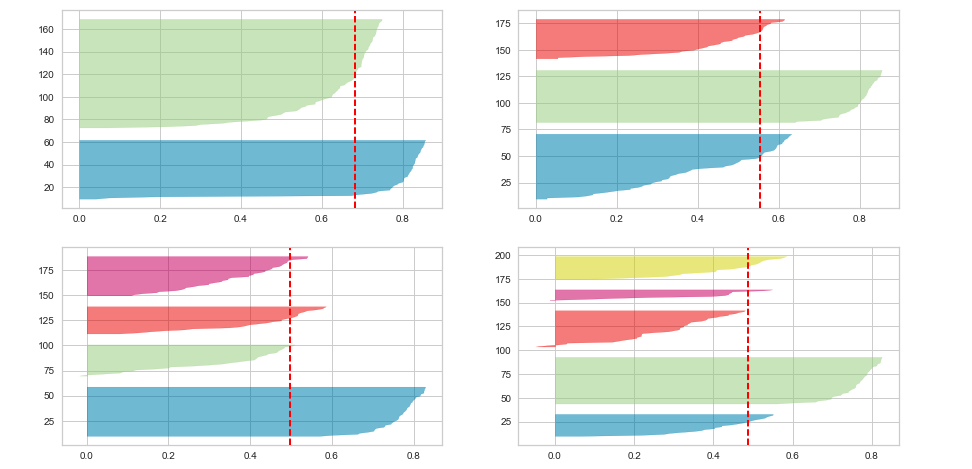

```python
from IPython.display import Image
Image(filename="silhouette.png", width=500, height=500)
```

For silhoutte scores, we want the average diameter of a cluster, b, to be smaller than the aversge distance to another cluster, a. We want b-a to be large as this means that the clusters are farther than their diameters. In other words, anything beyond average is good, but wwe also need to check if the silhouette scores are even or skewed across data points and if the proportions are similar among clusters. For these reasons, I would pick K 2 and 3, the top 2 silhouette plots.

### Hierarchical Clustering

Using the following dataset:

| Point | x | y |
| --- | --- | --- |
| A | 0 | 0 |
| B | 1 | 1 |
| C | 3 | 0 |
| D | 0 | 1 |
| E | 2 | 2 |

with

d = Euclidean  
D = Single-Link

produce the distance matrix at every step of the hierarchical clustering algorithm.

Step 1

|  | A | B | C | D | E |
| --- | --- | --- | --- | --- | --- |
| A | 0 | √2 | 3 | 1 | √8 |
| B | √2 | 0 | √5 | 1 | √2 |
| C | 3 | √5 | 0 | √10 | √5 |
| D | 1 | 1 | √10 | 0 | √5 |
| E | √8 | √2 | √5 | √5 | 0 |

Step 2

|  | A&D | B | C | E |
| --- | --- | --- | --- | --- |
| A&D | 0 | 1 | 3 | √5 |
| B | 1 | 0 | √5 | √2 |
| C | 3 | √5 | 0 | √5 |
| E | √5 | √2 | √5 | 0 |

Step 3

|  | A&D&B | C | E |
| --- | --- | --- | --- |
| A&D&B | 0 | √5 | √2 |
| C | √5 | 0 | √5 |
| E | √2 | √5 | 0 |

Step 4

|  | A&D&B&E | C |
| --- | --- | --- |
| A&D&B&E | 0 | √5 |
| C | √5 | 0 |

Repeat the above with

d = Euclidean  
D = Complete-Link

Step 1

|  | A | B | C | D | E |
| --- | --- | --- | --- | --- | --- |
| A | 0 | √2 | 3 | 1 | √8 |
| B | √2 | 0 | √5 | 1 | √2 |
| C | 3 | √5 | 0 | √10 | √5 |
| D | 1 | 1 | √10 | 0 | √5 |
| E | √8 | √2 | √5 | √5 | 0 |

Step 2

|  | A&D | B | C | E |
| --- | --- | --- | --- | --- |
| A&D | 0 | √2 | √10 | √8 |
| B | √2 | 0 | √5 | √2 |
| C | √10 | √5 | 0 | √5 |
| E | √8 | √2 | √5 | 0 |

Step 3

|  | A&D&B | C | E |
| --- | --- | --- | --- |
| A&D&B | 0 | √10 | √8 |
| C | √10 | 0 | √5 |
| E | √8 | √5 | 0 |

Step 4

[output not shown]

## Challenge Problem

### Input:

- Some DNA sequences, each sequence is on a new line. All sequences are of equal length and consist of characters from the set {A, C, G, T}.

### Task:

- Implement a hierarchical clustering algorithm using Hamming distance as the metric clustering DNA sequences.

### Definition of Hamming Distance:

The Hamming distance between two strings of equal length is the number of positions at which the corresponding symbols are different. Mathematically, if we have two strings, $s$ and $t$, of equal length, then the Hamming distance $H(s, t)$ is given by:

$$ H(s, t) = \sum_{i=1}^{n} [s_i \neq t_i] $$

where $n$ is the length of the strings, $s_i$ and $t_i$ are the characters at position $i$ in $s$ and $t$ respectively, and $[s_i \neq t_i]$ is an indicator function, equal to 1 if $s_i \neq t_i$ and 0 otherwise.

### Guidelines:

1. **Read the Dataset**: Choose appropriate data structure.
2. **Compute Hamming Distance**: Implement a function to calculate the Hamming distance between any two sequences.
3. **Hierarchical Clustering**: Apply the hierarchical clustering algorithm using the single-linkage method.
4. **Dendrogram**: Generate a dendrogram to visualize the clustering.
5. **NOTE**: You may use any Python library, but be sure to understand the underlying algorithm.

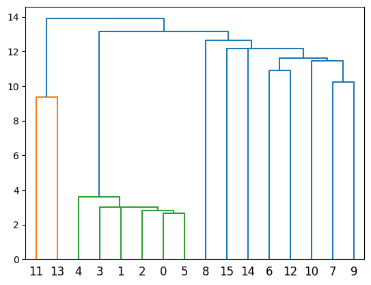

```python
from scipy.cluster.hierarchy import linkage, dendrogram
import matplotlib.pyplot as plt
import numpy as np

sequences = [
 'ACGTGGTCTTAA',
 'ACGTCGTCTTAC',
 'ACGTGGTCTTAC',
 'ACGTAGTCTTAA',
 'ACGTGGTCTTCC',
 'ACGTGGTCTTAG',
 'CTGTTAAATAAG',
 'GGTTAGAACACG',
 'AGTGGTTGAAGT',
 'GGCTTACACCCT',
 'AGATTGTCCACT',
 'CATGCGGTCAAC',
 'ATATATCATAGC',
 'TTTGCGGTTGGA',
 'GAATGGTCAGAA',
 'GTGATGCTGTCT']

s1 = sequences[0]
s2 = sequences[1]

def hamming_dist(s, t):
    dist = 0
    for i in range(len(s)): #since equal length strings
        if s[i] != t[i]: #count to distance if corresponding symbols are different
            dist += 1
    return dist

# hamming_dist(s1, s2)

def get_distance_matrix(sequences):
    len_seq = len(sequences)
    dist_matrix = np.zeros((len_seq, len_seq)) #initialize to empty n x n array of the length of the sequence

    for i in range(len_seq):
        for j in range(i+1, len_seq):
            dist_matrix[i][j] = hamming_dist(sequences[i], sequences[j]) #calculate the hamming distance for each data point in the matrix
            dist_matrix[j][i] = dist_matrix[i][j] #mirror

    return dist_matrix

#get_distance_matrix(sequences)
def hierachical_clustering_singlelink(sequences):
    distance_matrix = get_distance_matrix(sequences)
    linkage_matrix = linkage(distance_matrix, method="single") #Performs hierarchical/agglomerative clustering on the (hamming) distance matrix
    dendrogram(linkage_matrix) #use scipy's dendrogram function to illustrate how eaxch cluster is composed
    plt.show()

hierachical_clustering_singlelink(sequences)
```